# Welcome to Project 2! 😊

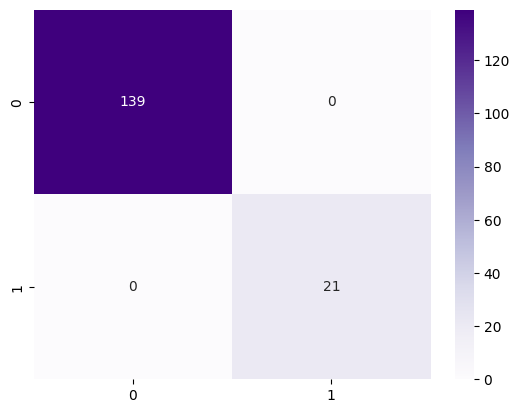

```python
sns.heatmap(conf_mat, annot=True, fmt='d', cmap='Purples')
```

```python
print(classification_report(y_test, y_pred))
```

```
              precision    recall  f1-score   support

           0       1.00      1.00      1.00       139
           1       1.00      1.00      1.00        21

    accuracy                           1.00       160
   macro avg       1.00      1.00      1.00       160
weighted avg       1.00      1.00      1.00       160
```

Getting a 100% accuracy shows that our model is completely overfit! It is acting too well and doesn't show any signs of struggling to understand the data, meaning that the model is not really predicting anything, but rather just regurgitating the information that is already given! It's not actually "learning" from the training and testing datasets! Let's see what's going on behind the scenes!!!

```python
dataset['is_legendary'].value_counts() # seeing the differences in what the model already knows to be legendary vs non legendary!
```

```
is_legendary
0    730
1     70
Name: count, dtype: int64
```

```python
X.columns # lets match the feature importances to the column names easier!
```

```
Index(['attack', 'base_egg_steps', 'capture_rate', 'defense',
       'experience_growth', 'height_m', 'hp', 'sp_attack', 'sp_defense',
       'speed', 'percentage_male'],
      dtype='object')
```

```python
print(tree_model.feature_importances_) # definitely would have came in handy to know this beforehand by using a pairplot, but still good information to know about what the model is using!
```

```
[0.02017845 0.88958832 0.06813301 0.         0.         0.
 0.02210021 0.         0.         0.         0.        ]
```

As you can see from our feature importance method, you can see that the 'base_egg_steps' is the biggest feature that is being used to determine what Pokemon is actually legendary vs what isn't. The other features such as attack, capture rate, and defense have basically little to nothing to contribute when it comes to the model!

Let's see what the decision tree says and how this outcome was determined!

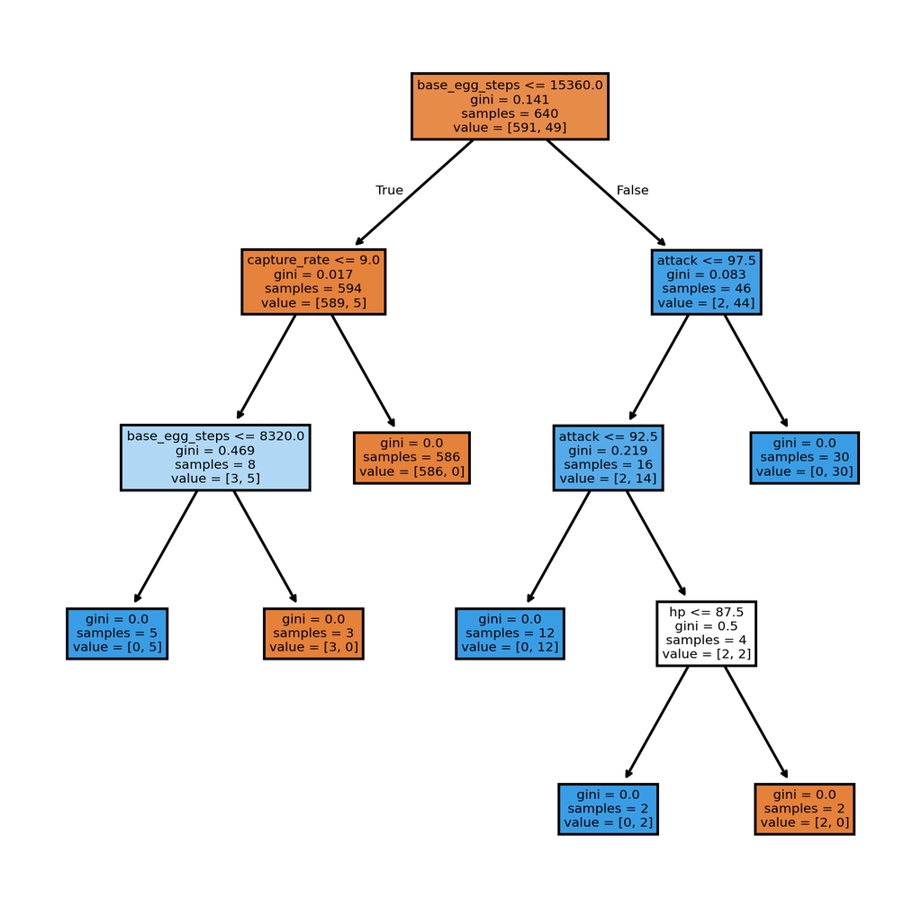

```python
# gathered from our SciKit Demo Part 1!! Thanks Dr. Benedict :D
fig, axes = plt.subplots(nrows = 1,ncols = 1, figsize = (6,6), dpi=300)
tree.plot_tree(tree_model, max_depth = 5, feature_names = X.columns, filled=True)
plt.show()
```

From the decision tree, you can figure out what the model deemed to be important features, along with why decisions were made! The root of the tree contains the most important feature, base_egg_steps. 🥚

base_egg_steps is then split between a certain threshold, also decided by the model. 🥚

The biggest features from this decision tree model are:

- base_egg_steps 🥚
- capture_rate
- attack
- hp

# Experiment 2 - Decision Tree pt. 2! :)

🔥💧🍃🔥💧🍃🔥💧🍃🔥💧🍃🔥💧🍃🔥💧🍃🔥💧🍃🔥💧🍃🔥💧🍃🔥💧🍃🔥💧🍃🔥💧🍃🔥💧🍃🔥💧🍃🔥💧🍃🔥💧🍃🔥💧🍃🔥💧🍃🔥💧🍃🔥💧🍃

Now, we will experiment without the genders (percentage_male) and see what kind of differences we can find by doing this experiment. We should also see how the model does without capture_rate and base_egg_steps, the 2 most important features of the first experiment! I want to know if the other features that are not capture_rate and base_egg_steps will increase in importance, due to the weight of most of the model shifting to base_egg_steps in the first experiment. My hypothesis says yes, but I fear the accuracy will suffer just a tad. But let's see what happens!

```python
dataset = dataset.drop(columns=['capture_rate','base_egg_steps', 'percentage_male'])
```

```python
dataset # making sure that the columns were actually dropped before splitting the dataset for training and testing!
```

|  | attack | defense | experience_growth | height_m | hp | sp_attack | sp_defense | speed | is_legendary |
| --- | --- | --- | --- | --- | --- | --- | --- | --- | --- |
| 0 | 49 | 49 | 1059860 | 0.7 | 45 | 65 | 65 | 45 | 0 |
| 1 | 62 | 63 | 1059860 | 1.0 | 60 | 80 | 80 | 60 | 0 |
| 2 | 100 | 123 | 1059860 | 2.0 | 80 | 122 | 120 | 80 | 0 |
| 3 | 52 | 43 | 1059860 | 0.6 | 39 | 60 | 50 | 65 | 0 |
| 4 | 64 | 58 | 1059860 | 1.1 | 58 | 80 | 65 | 80 | 0 |
| ... | ... | ... | ... | ... | ... | ... | ... | ... | ... |
| 796 | 101 | 103 | 1250000 | 9.2 | 97 | 107 | 101 | 61 | 1 |
| 797 | 181 | 131 | 1250000 | 0.3 | 59 | 59 | 31 | 109 | 1 |
| 798 | 101 | 53 | 1250000 | 5.5 | 223 | 97 | 53 | 43 | 1 |
| 799 | 107 | 101 | 1250000 | 2.4 | 97 | 127 | 89 | 79 | 1 |
| 800 | 95 | 115 | 1250000 | 1.0 | 80 | 130 | 115 | 65 | 1 |

800 rows × 9 columns

Let's train our model!! 🏋

```python
X = dataset.drop('is_legendary', axis=1)
y = dataset['is_legendary']
```

```python
X # making sure that the feature that we want to predict is gone!
```

|  | attack | defense | experience_growth | height_m | hp | sp_attack | sp_defense | speed |
| --- | --- | --- | --- | --- | --- | --- | --- | --- |
| 0 | 49 | 49 | 1059860 | 0.7 | 45 | 65 | 65 | 45 |
| 1 | 62 | 63 | 1059860 | 1.0 | 60 | 80 | 80 | 60 |
| 2 | 100 | 123 | 1059860 | 2.0 | 80 | 122 | 120 | 80 |
| 3 | 52 | 43 | 1059860 | 0.6 | 39 | 60 | 50 | 65 |
| 4 | 64 | 58 | 1059860 | 1.1 | 58 | 80 | 65 | 80 |
| ... | ... | ... | ... | ... | ... | ... | ... | ... |
| 796 | 101 | 103 | 1250000 | 9.2 | 97 | 107 | 101 | 61 |
| 797 | 181 | 131 | 1250000 | 0.3 | 59 | 59 | 31 | 109 |
| 798 | 101 | 53 | 1250000 | 5.5 | 223 | 97 | 53 | 43 |
| 799 | 107 | 101 | 1250000 | 2.4 | 97 | 127 | 89 | 79 |
| 800 | 95 | 115 | 1250000 | 1.0 | 80 | 130 | 115 | 65 |

800 rows × 8 columns

```python
X_train, X_test, y_train, y_test = train_test_split(X, y, test_size=0.2, random_state=42) # your typical train_test_split! :)
```

```python
X_train.shape, X_test.shape, y_train.shape, y_test.shape # making sure that the shapes of the new datasets are correct
```

```
((640, 8), (160, 8), (640,), (160,))
```

```python
dt_model = DecisionTreeClassifier(random_state=42) # the random state seed is here for reproducability :)
```

```python
dataset.info() # let's see what we're working with
```

```
<class 'pandas.core.frame.DataFrame'>
Index: 800 entries, 0 to 800
Data columns (total 9 columns):
 #   Column             Non-Null Count  Dtype
---  ------             --------------  -----
 0   attack             800 non-null    int64
 1   defense            800 non-null    int64
 2   experience_growth  800 non-null    int64
 3   height_m           780 non-null    float64
 4   hp                 800 non-null    int64
 5   sp_attack          800 non-null    int64
 6   sp_defense         800 non-null    int64
 7   speed              800 non-null    int64
 8   is_legendary       800 non-null    int64
dtypes: float64(1), int64(8)
memory usage: 62.5 KB
```

```python
dt_model.fit(X_train, y_train) # let's fit the training datasets to the model and let's see what we get!
```

```
DecisionTreeClassifier(random_state=42)
```

```python
# testing the accuracy of the model to see how the model performed!
accuracy = dt_model.score(X_test, y_test)
print(f"Accuracy: {accuracy}")
```

```
Accuracy: 0.91875
```

Our accuracy actually turned out pretty well!! :)

About 91% of the time the model was able to correctly predict the outcome if the Pokemon would be legendary or not. I'll take my chances with that!

```python
dataset['is_legendary'].value_counts()
```

```
is_legendary
0    730
1     70
Name: count, dtype: int64
```

This shows us that most of the Pokemon that are in our dataset are actually not legendary, and since the split between them are not a roughly 50/50 split, it feels like the model isn't even learning anything, it's just taking guesses that most of the Pokemon are not going to be legendary Pokemon!

Let's try seeing what the model is predicting and go from there!

```python
y_pred = dt_model.predict(X_test)
conf = confusion_matrix(y_test, y_pred)
```

For reference, here is what the confusion matrix values represent! Courtesy of Daniel from SciKit Demo Part 2 :)

|  | Predicted: Not Fraud (0) | Predicted: Fraud (1) |
| --- | --- | --- |
| **Actual: Not Fraud (0)** | True Negative (TN) | False Positive (FP) |
| **Actual: Fraud (1)** | False Negative (FN) | True Positive (TP) |

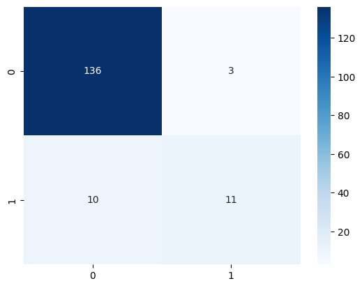

```python
sns.heatmap(conf, annot=True, fmt='d', cmap='Blues') # making the confusion matrix nice and pretty :)
```

```python
classification = classification_report(y_test, y_pred)
print(classification)
```

```
              precision    recall  f1-score   support

           0       0.93      0.98      0.95       139
           1       0.79      0.52      0.63        21

    accuracy                           0.92       160
   macro avg       0.86      0.75      0.79       160
weighted avg       0.91      0.92      0.91       160
```

This shows that our model was able to predict the results of the Pokemon not being legendary was way better than the model trying to predict if the Pokemon is Legendary. Let's see what features are most influencing this model!

```python
print(X.columns)
print(dt_model.feature_importances_)
```

```
Index(['attack', 'defense', 'experience_growth', 'height_m', 'hp', 'sp_attack',
       'sp_defense', 'speed'],
      dtype='object')
[0.08683845 0.08961906 0.24273252 0.06380599 0.0562546  0.11906656
 0.09037003 0.25131279]
```

The feature that has the most importance would be speed! experience_growth and speed were really almost tied for 1st place, with sp_attack being in 3rd.

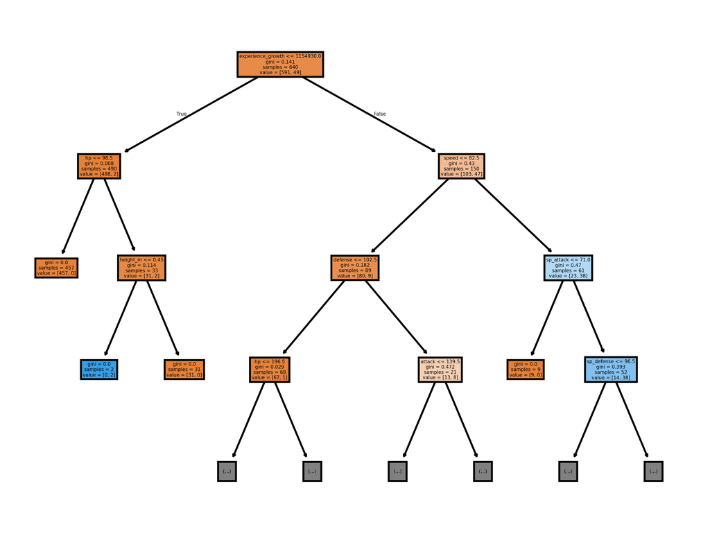

```python
# absolutely snatched this from our SciKit Demo Part 1!! Thanks Daniel!! :)
fig, axes = plt.subplots(nrows = 1,ncols = 1, dpi=600)
tree.plot_tree(dt_model, max_depth = 3, feature_names = X.columns, filled=True) # decided to do a max depth of 3 to keep it readable, but the tree definitely goes deeper than that!
plt.show()
```

Let's try doing another experiment but using Random Forest and seeing what the different models get in terms of accuracy and other metrics!

# Experiment 3 - Random Forest 🌳

🔥💧🍃🔥💧🍃🔥💧🍃🔥💧🍃🔥💧🍃🔥💧🍃🔥💧🍃🔥💧🍃🔥💧🍃🔥💧🍃🔥💧🍃🔥💧🍃🔥💧🍃🔥💧🍃🔥💧🍃🔥💧🍃🔥💧🍃🔥💧🍃🔥💧🍃🔥💧🍃

What is Random Forest? A Random Forest is an ensemble of Decision Trees working together to create a singular model, the Random Forest. "Ensemble learning is a type of learning where you join different types of algorithms or the same algorithm multiple times to form a more powerful prediction model."  
By Medium (Link to article: https://medium.com/@bestshivam15/random-forests-classifiers-e16dbc22ca5d)

```python
dataset # keeping the same dataset as before, just to be comparable to the decision tree model!
```

|  | attack | defense | experience_growth | height_m | hp | sp_attack | sp_defense | speed | is_legendary |
| --- | --- | --- | --- | --- | --- | --- | --- | --- | --- |
| 0 | 49 | 49 | 1059860 | 0.7 | 45 | 65 | 65 | 45 | 0 |
| 1 | 62 | 63 | 1059860 | 1.0 | 60 | 80 | 80 | 60 | 0 |
| 2 | 100 | 123 | 1059860 | 2.0 | 80 | 122 | 120 | 80 | 0 |
| 3 | 52 | 43 | 1059860 | 0.6 | 39 | 60 | 50 | 65 | 0 |
| 4 | 64 | 58 | 1059860 | 1.1 | 58 | 80 | 65 | 80 | 0 |
| ... | ... | ... | ... | ... | ... | ... | ... | ... | ... |
| 796 | 101 | 103 | 1250000 | 9.2 | 97 | 107 | 101 | 61 | 1 |
| 797 | 181 | 131 | 1250000 | 0.3 | 59 | 59 | 31 | 109 | 1 |
| 798 | 101 | 53 | 1250000 | 5.5 | 223 | 97 | 53 | 43 | 1 |
| 799 | 107 | 101 | 1250000 | 2.4 | 97 | 127 | 89 | 79 | 1 |
| 800 | 95 | 115 | 1250000 | 1.0 | 80 | 130 | 115 | 65 | 1 |

800 rows × 9 columns

```python
dataset.info() # making sure the info of the dataset is the same
```

```
<class 'pandas.core.frame.DataFrame'>
Index: 800 entries, 0 to 800
Data columns (total 9 columns):
 #   Column             Non-Null Count  Dtype
---  ------             --------------  -----
 0   attack             800 non-null    int64
 1   defense            800 non-null    int64
 2   experience_growth  800 non-null    int64
 3   height_m           780 non-null    float64
 4   hp                 800 non-null    int64
 5   sp_attack          800 non-null    int64
 6   sp_defense         800 non-null    int64
 7   speed              800 non-null    int64
 8   is_legendary       800 non-null    int64
dtypes: float64(1), int64(8)
memory usage: 62.5 KB
```

```python
X = dataset.drop('is_legendary', axis=1)
y = dataset['is_legendary']
```

```python
X_train, X_test, y_train, y_test = train_test_split(X, y, test_size=0.2, random_state=42) # nice little split :P
```

```python
X_train.shape, X_test.shape, y_train.shape, y_test.shape # making sure that the train and test datasets are the correct shapes!
```

```
((640, 8), (160, 8), (640,), (160,))
```

```python
random_model = RandomForestClassifier(random_state=42) # the random state seed is here for reproducability :)
```

```python
random_model.fit(X_train, y_train) # lets fit the model to our training dataset
```

```
RandomForestClassifier(random_state=42)
```

```python
# let's see how the model performed!
accuracy = random_model.score(X_test, y_test)
print(f"Accuracy: {accuracy}")
```

```
Accuracy: 0.9125
```

The model actually performed pretty much the same as Experiment #2 the Decision Tree Classifier! Even though Random Forest uses many more trees than Decision Tree, it kind of makes sense that they would have the same accuracy. Decision tree just shows you the process whereas Random Forest doesn't, it's more of a black box "here's what we did".

```python
y_pred = random_model.predict(X_test)
conf_matrix = confusion_matrix(y_test, y_pred)
```

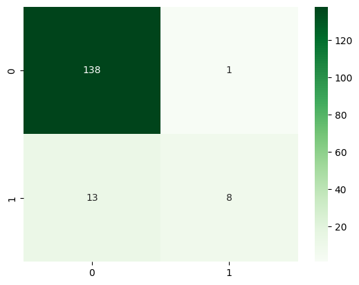

```python
sns.heatmap(conf_matrix, annot=True, fmt='d', cmap='Greens')
```

From the confusion matrix above, you can see that there was a lot of True Negatives that were discovered, which lines up with the training dataset, where most of the Pokemon in the dataset were actually not Legendaries! You can also see that only a small percentage is actually Legendaries, which is super crazy but accurate. If we had a bunch of Legendary Pokemon, would they really be Legendary?

Let's see what the feature importances are of the features given and see if their importances are any different from the Experiment #2 Decision Tree model! :)

```python
print(X.columns)
print(random_model.feature_importances_)
```

```
Index(['attack', 'defense', 'experience_growth', 'height_m', 'hp', 'sp_attack',
       'sp_defense', 'speed'],
      dtype='object')
[0.07265631 0.08696451 0.1652408  0.13415446 0.12033048 0.15538481
 0.11833838 0.14693026]
```

```python
report = classification_report(y_test, y_pred)
print(report)
```

```
              precision    recall  f1-score   support

           0       0.91      0.99      0.95       139
           1       0.89      0.38      0.53        21

    accuracy                           0.91       160
   macro avg       0.90      0.69      0.74       160
weighted avg       0.91      0.91      0.90       160
```

Let's go back to what these metrics mean!!

- Precision: This value tells us that out of all of the Pokemon that were predicted to be Legendary, how many are actually not Legendary?
- Recall: Out of the total amount of Pokemon that are not Legendary, how many does the model actually catch as not Legendary?
- F1-Score: This score actually balances both precision and recall together!!

🔥💧🍃🔥💧🍃🔥💧🍃🔥💧🍃🔥💧🍃🔥💧🍃🔥💧🍃🔥💧🍃🔥💧🍃🔥💧🍃🔥💧🍃🔥💧🍃🔥💧🍃🔥💧🍃🔥💧🍃🔥💧🍃🔥💧🍃🔥💧🍃🔥💧🍃🔥💧🍃